# Exploração de dados Goiás

## Percentual de funcionários efetivos com formação voltada para a agropecuária.

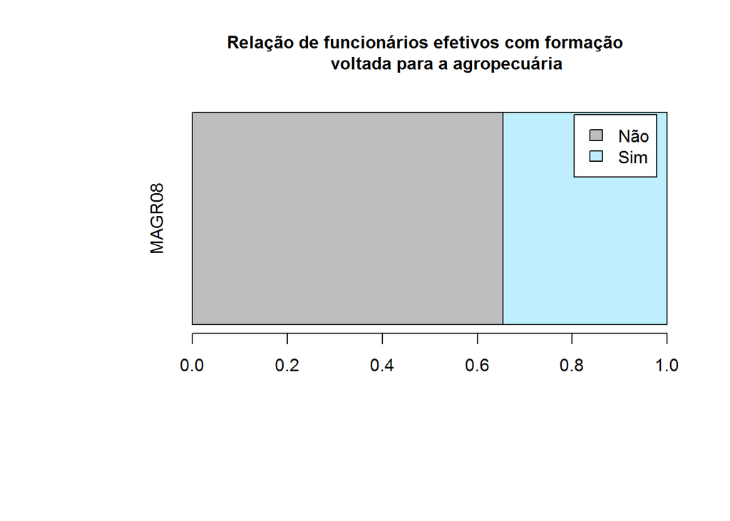

Cerca de 35% dos municípios possuem funcionários efetivos com formação voltada para a agropecuária.

## Qual o percentual da existência de programa ou ação de estímulo à Agricultura orgânica?

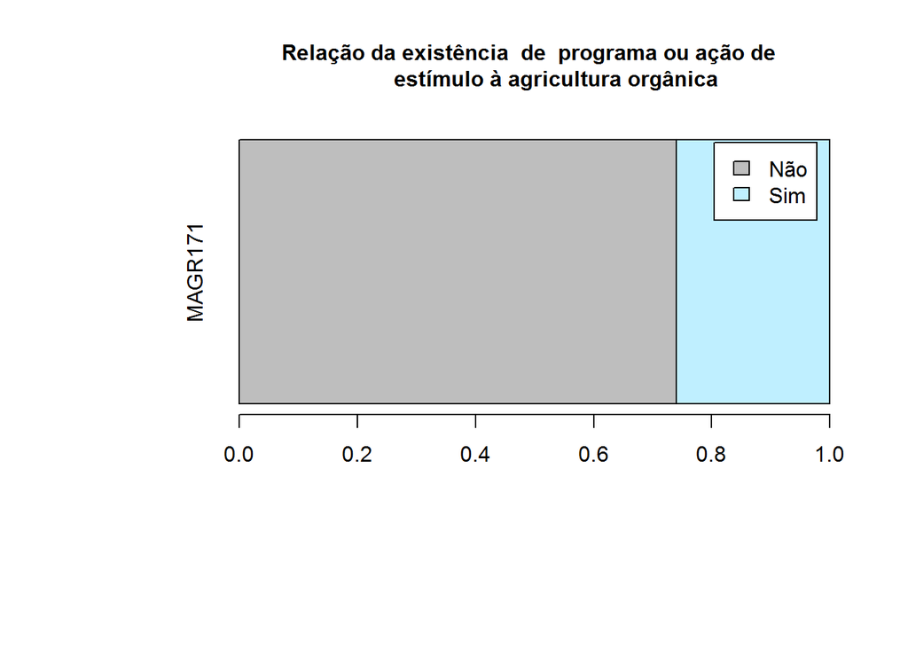

## Meio ambiente

## Qual o percentual de municípios que possuem Plano de Gestão Integrada de Resíduos Sólidos?

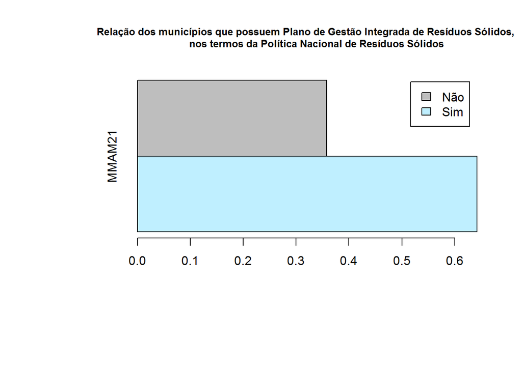

Mais de 60% dos municípios possuem plano de Gestão Integrada de Resíduos Sólidos.

## Qual o percentual da existência de Legislação ou instrumento de gestão ambiental sobre a fauna silvestre?

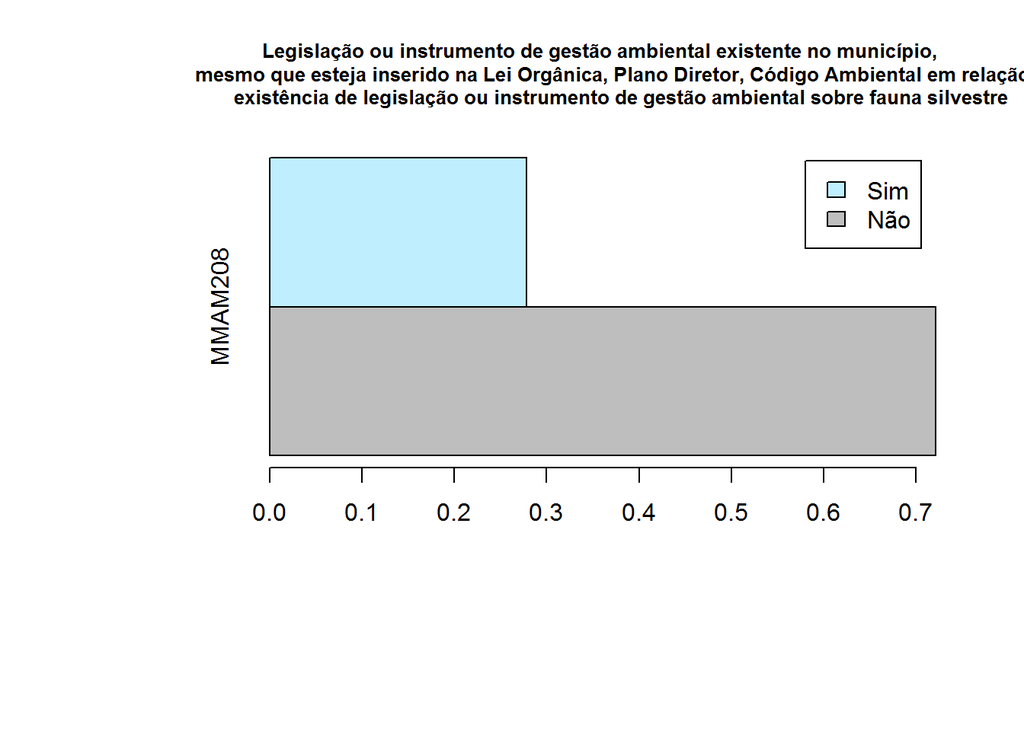

Um pouco menos de 30% dos municípios possuem legislação ou instrumento de gestão ambiental sobre a fauna silvestre.

## Qual o percentual da existência de Legislação ou instrumento de gestão ambiental sobre destino das embalagens de produtos agrotóxicos nos municípios?

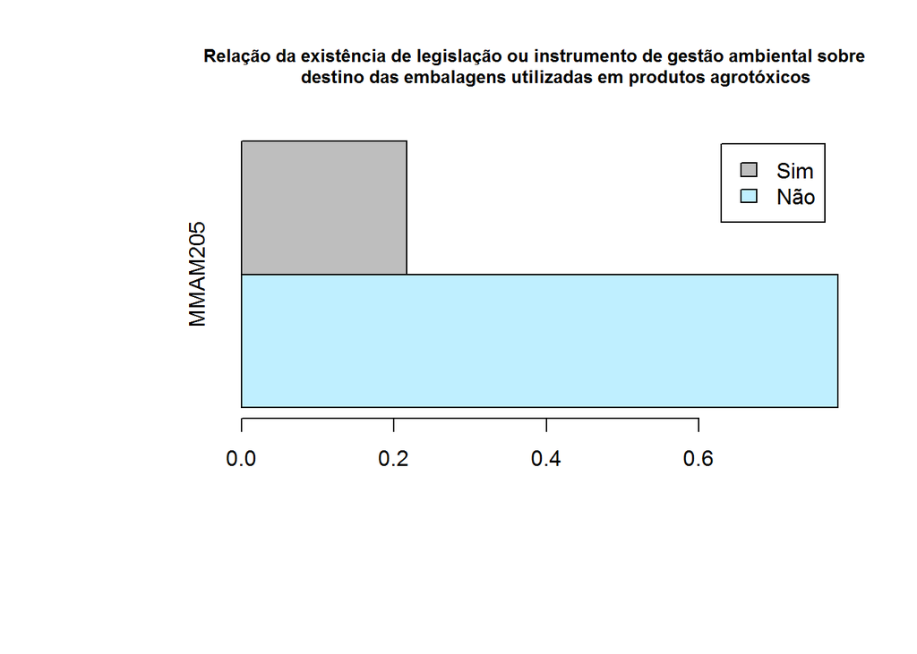

Cerca de 20% dos municípios possuem legislação ou instrumento de gestão ambiental sobre destino das embalagens de produtos agrotóxicos.

## Quais os impactos ambientais e/ou processos/ações de maior ocorrência nos municípios de Goiás?

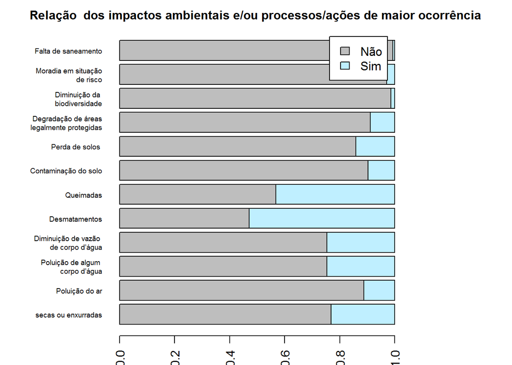

Os impactos ambientais e/ou processos/ações de maior ocorrência são: Desmatamento e queimada.

## Qual a porcentagem de municípios que participaram de capacitação promovida pelo governo federal na área de meio ambiente nos últimos 4 anos?

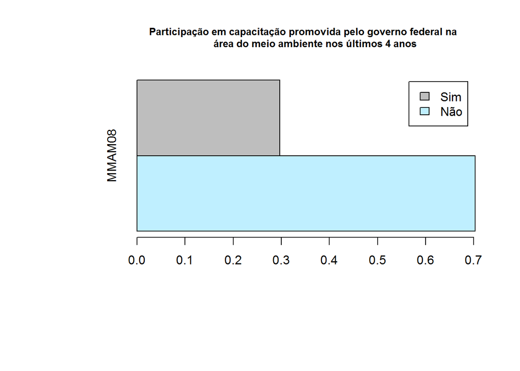

Cerca de 30% dos municípios participaram de capacitação promovida pelo governo federal na área de meio ambiente.

## Gestão de riscos e resposta a desastres

## Qual a porcentagem de municípios atingidos por secas nos últimos 4 anos?

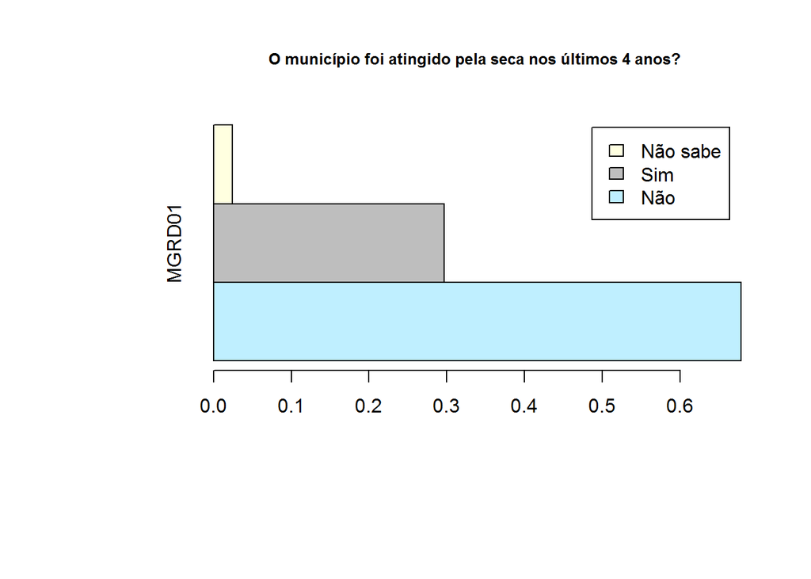

Cerca de 30% dos municípios foram atingidos pela seca.

## Qual a porcentagem de municípios atingidos por alagamentos nos últimos 4 anos?

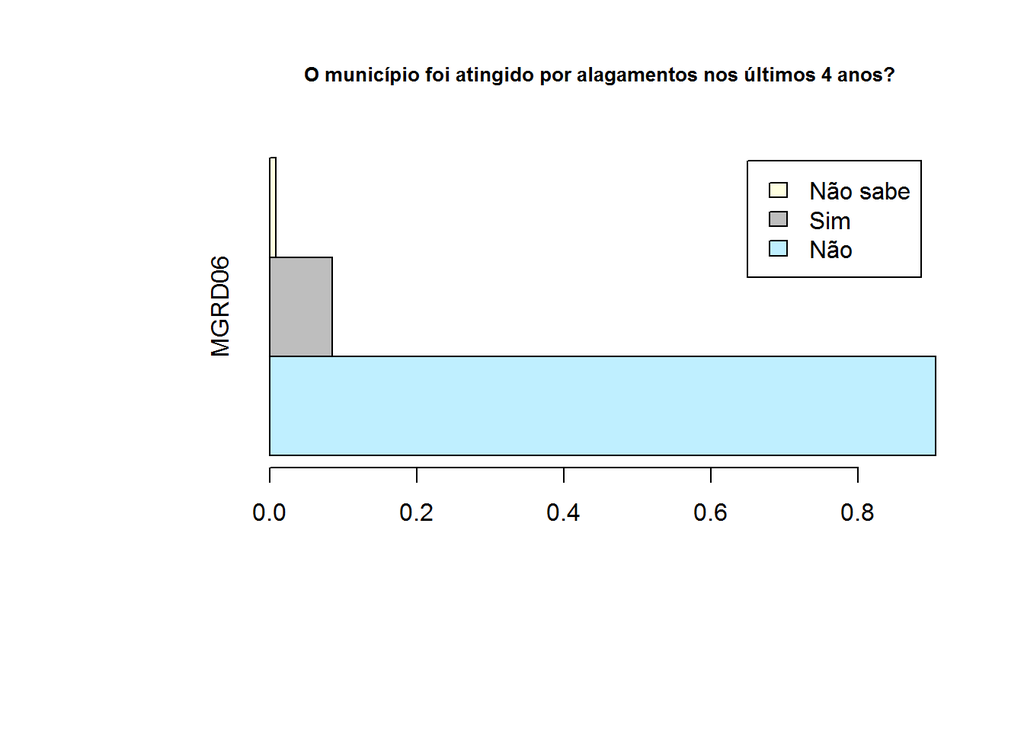

Menos de 10% dos Municípios foram atingidos por alagamentos nos últimos 4 anos

## Os municípios do estado de Goiás implementaram intervenções para minimizar as enchentes ou inundações graduais?

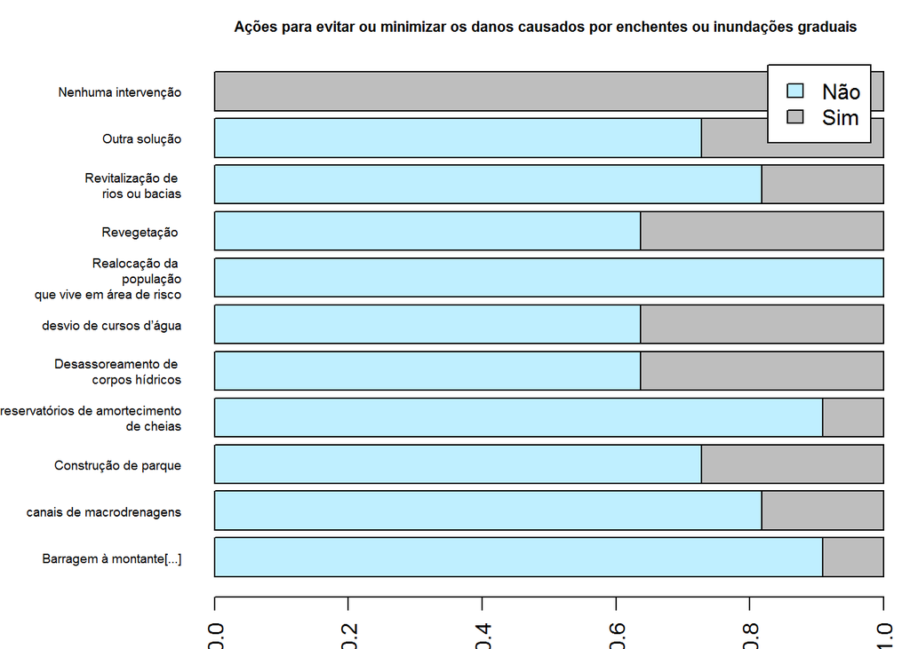

## Qual a porcentagem da existência de Unidades de corpo de bombeiros nos municípios?

```
##          [,1] [,2] [,3]
## Não 0.3166667  0.4 0.95
## Sim 0.6833333  0.6 0.05
```

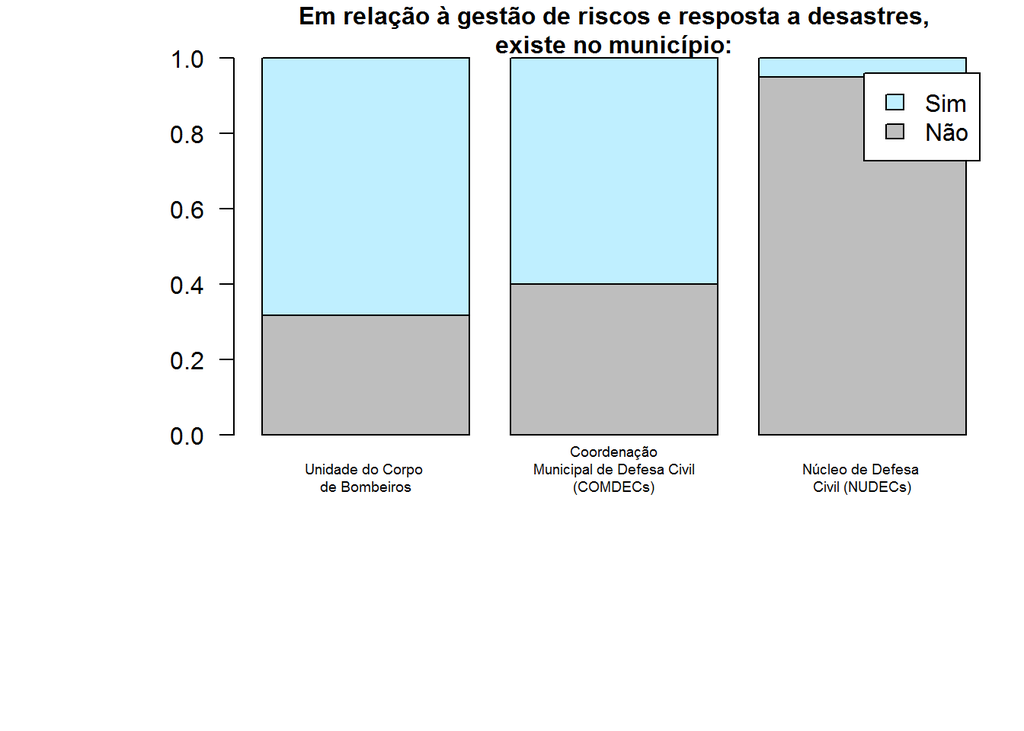

Mais de 60% dos municípios possuem Unidade de corpo de bombeiros.

## Os municípios do estado de Goiás possuem plano de contingência em relação ao gerenciamento de riscos de desastres decorrentes de enchentes ou inundações graduais,ou enxurradas ou inundações bruscas?

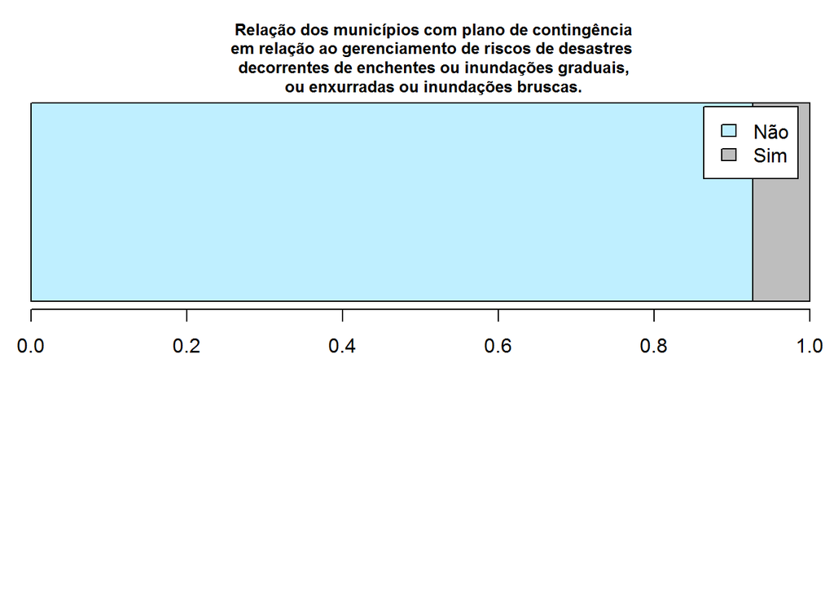

Mais de 90% dos municípios não possuem o plano de contingência.